# Recent advances in the remote sensing of insects - Rhodes - 2022 - Biological Reviews - Wiley Online Library

[Biological Reviews](https://onlinelibrary.wiley.com/journal/1469185x)

[Volume 97, Issue 1](https://onlinelibrary.wiley.com/toc/1469185x/2022/97/1) p. 343-360

[figure not shown]

Original Article

Full Access

# Recent advances in the remote sensing of insects

[Marcus W. Rhodes](https://onlinelibrary.wiley.com/authored-by/Rhodes/Marcus+W.),

[Jonathan J. Bennie](https://onlinelibrary.wiley.com/authored-by/Bennie/Jonathan+J.),

[Adrian Spalding](https://onlinelibrary.wiley.com/authored-by/Spalding/Adrian),

[Richard H. ffrench-Constant](https://onlinelibrary.wiley.com/authored-by/ffrench%E2%80%90Constant/Richard+H.),

[Ilya M. D. Maclean](https://onlinelibrary.wiley.com/authored-by/Maclean/Ilya+M.+D.),

First published: 05 October 2021

https://doi.org/10.1111/brv.12802

Citations: 14

[Check for Full Text](https://onlinelibrary.wiley.com/servlet/linkout?suffix=s0&dbid=16384&doi=10.1111/brv.12802&type=tocOpenUrl&url=https%3A%2F%2Fufl-flvc.primo.exlibrisgroup.com%2Fopenurl%2F01FALSC_UFL%2F01FALSC_UFL%3AUFL%3F)

## ABSTRACT

Remote sensing has revolutionised many aspects of ecological research, enabling spatiotemporal data to be collected in an efficient and highly automated manner. The last two decades have seen phenomenal growth in capabilities for high-resolution remote sensing that increasingly offers opportunities to study small, but ecologically important organisms, such as insects. Here we review current applications for using remote sensing within entomological research, highlighting the emerging opportunities that now arise through advances in spatial, temporal and spectral resolution. Remote sensing can be used to map environmental variables, such as habitat, microclimate and light pollution, capturing data on topography, vegetation structure and composition, and luminosity at spatial scales appropriate to insects. Such data can also be used to detect insects indirectly from the influences that they have on the environment, such as feeding damage or nest structures, whilst opportunities for directly detecting insects are also increasingly available. Entomological radar and light detection and ranging (LiDAR), for example, are transforming our understanding of aerial insect abundance and movement ecology, whilst ultra-high spatial resolution drone imagery presents tantalising new opportunities for direct observation. Remote sensing is rapidly developing into a powerful toolkit for entomologists, that we envisage will soon become an integral part of insect science.

## I. INTRODUCTION

Remote sensing has revolutionised research in many fields of ecology and environmental science (Kerr & Ostrovsky, 2003; Chapman, Drake & Reynolds, 2011; Anderson & Gaston, 2013; Davies & Asner, 2014; Pettorelli *et al*., 2014; Nowak, Dziób & Bogawski, 2019; Zellweger *et al*., 2019). Monitoring of ecological phenomena is dependent upon observational data collected across time and space that is often labour-intensive and expensive to obtain *via* conventional field sampling (Turner *et al*., 2003). The last four decades have seen the emergence of increasingly versatile remote-sensing products, which can offer efficient and automated methods of capturing such data (Riley *et al*., 2007; Anderson & Gaston, 2013; Belward & Skøien, 2015). These have developed into powerful tools for ecological research, enabling data to be collected over much larger areas and at greater frequency than would otherwise be possible (Kerr & Ostrovsky, 2003; Anderson & Gaston, 2013).

Insects form a major component of Earth's biodiversity and play a crucial role in many ecosystem functions (Gullan & Cranston, 2010). Remote sensing of insects, however, presents considerable challenges, due to both the cryptic nature of many species, and the constraints imposed by the resolution of available data. Insects are often orders of magnitude smaller than the spatial resolution (pixel size) of many remote-sensing products, whilst the short life cycles of many species mean that key phenomena for their monitoring and detection can be easily missed at low temporal resolutions (long revisit times between data collection) (Senf, Seidl & Hostert, 2017). Consequently, both the organisms themselves, along with the fine-scale habitat features which they may rely on, can be difficult to detect remotely (Nansen & Elliott, 2016; Senf *et al*., 2017).

In spite of these limitations, remote-sensing applications have a long history within entomological research (Riley, 1989; Nansen & Elliott, 2016). In particular, extensive efforts have been directed towards the detection and monitoring of insect pests within agriculture and forestry settings (Latchininsky, 2013; Senf *et al*., 2017; Zhang *et al*., 2019; Iost Filho *et al*., 2020). Considerable potential remains to be realised, however, particularly in relation to broader aspects of studying insect ecology and conservation. Here, the use of remote sensing is still relatively rare (Leyequien *et al*., 2007; Galbraith, Vierling & Bosque-Pérez, 2015; Nowak *et al*., 2019), but as technology continues to advance, new avenues are opening rapidly.

The last two decades have witnessed phenomenal growth in the availability of very high resolution remote-sensing products. Satellite missions, such as the Copernicus Programme's Sentinel satellites, now offer ~10 m spatial resolutions with revisit times of less than a week, whilst sub-metre spatial resolutions at daily revisit times are now available from some commercial satellites (Drusch *et al*., 2012; Belward & Skøien, 2015) (Table 1). Affordable drone technology has rapidly emerged over this same period, offering localised surveys on demand and in unprecedented detail (Anderson & Gaston, 2013; Nowak *et al*., 2019), whilst a renaissance of entomological radar has transformed the monitoring of airborne insects (Chapman *et al*., 2011). These recent developments offer enormous potential for insect science, which we seek to highlight in this review.

Table 1. Temporal and spatial resolution of selected spectral bands for a range of Earth observation satellites

| Satellite/sensor | Data access | Operational | Temporal resolution | Spectral bands Panchromatic | Spectral bands Blue | Spectral bands Green | Spectral bands Red | Spectral bands Red edge | Spectral bands NIR | Spectral bands SWIR | Spectral bands TIR |
| --- | --- | --- | --- | --- | --- | --- | --- | --- | --- | --- | --- |
| MODIS | Open data | 1999–present | 1–2 days | – | 500 m | 500 m | 250 m | – | 250 m | 500 m | 1000 m |
| AVHRR/3 | Open data | 1978–present | <1 day | – | – | – | 1090 m | – | 1090 m | 1090 m | 1090 m |
| VIIRS | Open data | 2011–present | <1 day | 750 m | 750 m | 750 m | 375 m | – | 375 m | 375 m | 375 m |
| Landsat 8 | Open data | 2013–present | 18 days | 15 m | 30 m | 30 m | 30 m | – | 30 m | 30 m | 100 m |
| Sentinel-2 | Open data | 2015–present | 5 days | – | 10 m | 10 m | 10 m | 20 m | 10 m | 20 m | – |
| Sentinel-3 | Open data | 2016–present | <1 day | – | – | 500 m | 500 m | – | 500 m | 500 m | 1000 m |
| SPOT-6/7 | Commercial | 2012–present | <1 day | 1.5 m | 6 m | 6 m | 6 m | – | 6 m | – | – |
| Pleiades-1A/1B | Commercial | 2011–present | <1 day | 0.5 m | 2 m | 2 m | 2 m | – | 2 m | – | – |
| IKONOS | Commercial | 1999–2015 | 3–5 days | 0.82 m | 3.2 m | 3.2 m | 3.2 m | – | 3.2 m | – | – |
| GeoEye-1 | Commercial | 2008–present | <3 days | 0.41 m | 1.65 m | 1.65 m | 1.65 m | – | 1.65 m | – | – |
| WorldView-3 | Commercial | 2014–present | <1 day | 0.31 m | 1.24 m | 1.24 m | 1.24 m | 1.24 m | 1.24 m | 3.7 m | – |
| QuickBird | Commercial | 2001–2014 | 3–6 days | 0.65 m | 2.62 m | 2.62 m | 2.62 m | – | 2.62 m | – | – |

- NIR, near-infrared; SWIR, shortwave infrared; TIR, thermal infrared.

## II. REMOTE-SENSING TECHNIQUES

### (1) Platforms

For the purposes of this review, remote sensing is defined as the detection of emitted or reflected electromagnetic radiation from afar. Sensors capable of detecting electromagnetic radiation may be deployed from a range of ground-based, satellite and aerial (such as aircraft and drones) platforms, the choice of which is largely governed by trade-offs between spatial and temporal resolution, and the geographical extent of the data required (Nagendra, 2001). Airborne platforms, for example, can offer higher spatial resolution images than satellite platforms, as they are operating at much lower altitudes (Anderson & Gaston, 2013). Drone technology, in particular, has revolutionised fine-scale remote sensing in recent years, with slow, low-altitude flights offering data at centimetre resolutions (Anderson & Gaston, 2013; Nowak *et al*., 2019). Spatially fine-scale data, however, typically involve a trade-off with geographical extent. Due to constraints imposed by limited flight times and a narrow swath (geographical coverage of each flypast), aerial platforms are usually only suitable for regional (aircraft) or site-level (drones) surveys (Khorram *et al*., 2012). The revisit times of aerial platforms can, however, be defined by the end-user, although in practice high operational costs are often restrictive in this respect for aircraft surveys (Anderson & Gaston, 2013). Satellites, on the other hand, can offer global coverage, but the temporal resolution of these data is determined by the satellite's orbit and, for certain forms of data (e.g. optical data), also conditional on cloud-free conditions (Turner *et al*., 2003). Furthermore, higher temporal resolution for satellites has historically involved a cost of lower spatial resolution, however a new generation of Earth observation satellites (e.g. Sentinel-2) are now offering both fine-scale temporal and spatial coverage (Drusch *et al*., 2012) (Table 1). Very high spatial resolution (sub-metre) products are also increasingly available from a growing range of commercial satellites, but these can be costly to obtain data from and so most users will be restricted to a single image (Nagendra *et al*., 2013).

### (2) Sensors

Sensors supported by remote-sensing platforms can be categorised as either active or passive (Pettorelli *et al*., 2014). Active sensors emit their own radiation and then analyse the returning backscatter that is reflected back to them by objects. Passive sensors, on the other hand, measure the natural radiation, such as sunlight or thermal infrared, that is reflected or emitted by objects.

#### (a) *Optical sensors*

Optical sensors passively detect reflected electromagnetic radiation within the visible light (400–700 nm), near-infrared (NIR) (700–1400 nm) and shortwave infrared (SWIR) (1400–3000 nm) regions of the spectrum (Fig. 1). Depending on the application, the spectral resolution of instruments can range from panchromatic (single broad band) and standard red, green and blue (RGB) cameras (three band), through to multispectral and hyperspectral sensors that may comprise up to a dozen or hundreds of narrow spectral bands, respectively (Khorram *et al*., 2012). Panchromatic and RGB sensors mounted on satellite, aircraft or drone platforms provide aerial photographs for the mapping of landscape features, whilst the greater spectral resolution (more spectral bands with narrower sensitivity ranges) afforded by multispectral and hyperspectral sensors can assist with distinguishing vegetation characteristics (Khorram *et al*., 2012). Higher spectral resolution, however, typically involves a trade-off with an increased cost and payload of sensors (Iost Filho *et al*., 2020).

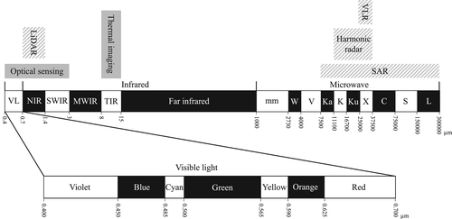

**Fig 1**

Open in figure viewer[PowerPoint](https://onlinelibrary.wiley.com/action/downloadFigures?id=brv12802-fig-0001&doi=10.1111%2Fbrv.12802)

A representation of the electromagnetic spectrum between wavelengths of 0.4 μm and 300,000 μm, highlighting the main regions used for the remote sensing of insects. Passive sensing methods are shown in solid boxes and active sensing methods in hashed boxes. LiDAR, light detection and ranging; MWIR, medium-wave infrared; NIR, near-infrared; SAR, synthetic aperture radar; SWIR, shortwave infrared; TIR, thermal infrared; VL, visible light; VLR, vertical-looking radar.

Analysing reflectance profile data may involve the interpretation of spectral signatures (e.g. specific peaks or troughs in the spectral profile) or the computation of vegetation indices derived from the ratios between different spectral bands (Iost Filho *et al*., 2020). Normalised Difference Vegetation Index (NDVI), for example, is a widely used index derived from the ratio between the reflectance of visible red light and NIR (Pettorelli *et al*., 2011). As photosynthesising vegetation absorbs visible red light but reflects radiation in the NIR region, NDVI provides an index of net primary productivity from which plant biomass and Leaf Area Index (LAI: one-sided leaf area per unit area of ground surface) can be estimated (Pettorelli *et al*., 2011).

#### (b) *Thermal imaging*

Thermal imaging measures the long-wave (thermal) infrared radiation (TIR) (8000–15000 nm) emitted by objects to derive estimates of their surface temperatures (Fig. 1). The relationship between temperature and radiation emittance is described by the Stefan–Boltzmann Law and is dependent upon the object's emissivity – how effectively its surface emits radiation (Vollmer & Möllmann, 2017). To obtain an accurate calculation of temperature, therefore, the emissivity of the surfaces being measured needs to be known. Most habitat surfaces have a broadly similar emissivity, with mean values falling between 0.903 and 0.997 for a wide range of vegetation, rock and soil types (Rubio, Caselles & Badenas, 1997). This variation can, nonetheless, still prove problematic where highly accurate measurements of surface temperature are required for heterogenous environments, but can increasingly be resolved with the use of image classification methods to differentiate surface types within an image (Faye *et al*., 2016). Thermal imagery from satellite platforms typically offers spatial resolution in the range of 100–1000 m (Table 1), whilst drone-mounted sensors are now capable of capturing thermal images at centimetre resolution. Thermal imaging can be used for applications such as the mapping of microclimate, monitoring plant health or distinguishing objects and organisms that thermally contrast with their surroundings. It should be noted, however, that such data only represent a snapshot of thermal conditions at a given moment in time. Multiple images at different times of day and year, and under different weather conditions will be necessary in order to capture the full variability of surface temperature through time (Bramer *et al*., 2018).

#### (c) *LiDAR*

Light detection and ranging (LiDAR) is a form of active sensing that uses NIR laser pulses to measure the distance of objects (Davies & Asner, 2014) (Fig. 1). The energy waveform of the backscattered laser light is used to calculate individual return times and produce a point cloud from which three-dimensional structure is determined (Vierling *et al*., 2008; Zellweger *et al*., 2019). In an ecological context, LiDAR can be used to map topography and vegetation structure at fine spatial resolutions (sub-metre), or can be used to detect small, airborne objects, such as insects (Davies & Asner, 2014; Brydegaard & Jansson, 2019). For mapping purposes, LiDAR systems are usually aircraft-mounted, enabling coverage of entire landscapes or regions (Davies & Asner, 2014). As laser pulses are generally wider than individual leaves when they encounter vegetation, some of the light is able to pass through the upper canopy to reach sub-canopy levels and the ground, providing information on vertical habitat structure (Zellweger *et al*., 2019). Sub-canopy vegetation structure can be captured in even greater detail with terrestrial laser scanning (TLS). Ground-based LiDAR systems, such as TLS or the various forms of entomological LiDAR (which may be scanning or a horizontal fixed-beam), can offer spatial resolutions of just a few millimetres, but are limited in geographical range to within just a few metres (for TLS) or hundreds of metres (for entomological LiDAR) (Vierling *et al*., 2008; Brydegaard & Jansson, 2019; Zellweger *et al*., 2019). At the other end of the scale, the Global Ecosystem Dynamic Investigation LiDAR (GEDI) is a new space-based system housed onboard the International Space Station. Beginning operation in 2019, it offers spatially coarse (~25 m footprint resolution), but temporally high resolution structural data at a global scale, between latitudes of 51.6°N and 51.6°S (Dubayah *et al*., 2020).

#### (d) *Radar*

Radio detection and ranging (radar) is a form of active sensing that uses microwaves (Fig. 1). Radar systems emit pulses of microwave radiation and then analyse the returning energy waveform that is reflected from objects. The returning backscatter at a given wavelength and polarisation can provide information on an object's structure and dielectric properties (e.g. water content) (Bergen *et al*., 2009). Synthetic-aperture radar (SAR) is deployed on moving platforms, such as satellites or aircraft, and is used for mapping topography and vegetation structure (Bergen *et al*., 2009). SAR data from satellite platforms are readily available at high temporal resolutions and have the advantage over LiDAR and optical methods of being unaffected by cloud cover (Bergen *et al*., 2009). Vertical-looking radar (VLR) is a ground-based system that is used to detect airborne objects passing through a narrow, conical beam above the transmitter (Chapman, Reynolds & Smith, 2003). It can be used for monitoring airborne insect activity and migration, capturing information on insect morphology, position, horizontal speed and direction of travel (Chapman *et al*., 2003). Harmonic radar is used for tracking insect movement at low altitudes over distances of <1 km (Chapman *et al*., 2011). A rotating, scanning radar emits a signal at a particular frequency, which is received by a small, passive transponder fitted to the insect being tracked. This transponder then re-emits the signal at a different frequency so that it can be detected by the receiver, allowing the insect's location to be determined (Chapman *et al*., 2011).

#### (e) *Structure-from-motion*

Structural information can also be obtained passively from aerial photographs using a process called structure-from-motion photogrammetry (SfM). SfM uses multiple, overlapping photographs taken from different camera positions to determine three-dimensional structure and camera pose simultaneously (Westoby *et al*., 2012). The process is fully automated and is now widely used as a method for mapping three-dimensional surfaces at centimetre resolutions from aerial drone images. The low operational costs and the user-defined flexibility of drone platforms are strong advantages of SfM, however, where vegetation cover is dense, it is less able to capture sub-canopy details compared to either LiDAR or radar (White *et al*., 2013; Wallace *et al*., 2016).

## III. HABITAT MAPPING

Mapping of habitats is amongst the oldest and most widespread uses of remote sensing within ecology (Pettorelli *et al*., 2014). Continuous data sets of aerial photographs extend as far back as the early 1930s in some cases (Morgan, Gergel & Coops, 2010), whilst long-term satellite programmes have been collecting multispectral imagery since the first Landsat mission was launched in 1972 (Belward & Skøien, 2015). These longstanding data sets have been used extensively by ecologists to quantify changes in land cover through time and to explore species' responses to the extent, connectivity and condition of habitats within landscapes (Kerr & Ostrovsky, 2003; Turner *et al*., 2003; Nagendra *et al*., 2013; Pettorelli *et al*., 2014). Habitat mapping has been widely used as a surrogate for species' distribution and abundance (Nagendra, 2001; Leyequien *et al*., 2007), whilst the ease with which remote-sensing data can be collated at different grain sizes has greatly facilitated investigation of species' responses to landscape structure across multiple spatial scales (Galbraith *et al*., 2015).

### (1) Vegetation indices

Vegetation indices derived from reflectance data have been used quite widely as a proxy for mapping insect diversity. The most commonly used index for this purpose is NDVI, as it relates to primary productivity, plant biomass and habitat complexity (Pettorelli *et al*., 2011). Spatial variation in NDVI, for example, has been used as a predictor of butterfly (Levanoni *et al*., 2011) and ant (Lassau *et al*., 2005) species richness, and to predict the abundance, richness and composition of beetle assemblages (Lassau & Hochuli, 2008). Using very high resolution NDVI satellite data (2 × 2 m) from WorldView-2, for example, Mairota *et al*. (2015) were able to model spatial patterns in lepidopteran and orthopteran diversity at varying grain sizes across calcareous grasslands in southern Italy. Their models incorporated both the standard deviation of NDVI and metrics relating to image texture for each nested sample site. Seasonal changes in vegetation indices have also been used as a proxy for insect phenology. Normalised difference water index (NDWI) and snow melt dates derived from MODIS satellite data, for example, have been used to predict the peak flight periods of moth species in Finland (Pöyry *et al*., 2018). Similarly, satellite-derived NDVI has been used as a predictor of honeybee (*Apis mellifera*) hive phenology (Nightingale *et al*., 2008), whilst ground-based measurements of NDVI have been used to predict seasonal changes in tundra arthropod biomass (Sweet *et al*., 2015). With drone platforms, it is now even possible to capture phenological changes in vegetation at the scale of individual tree crowns (Fawcett, Bennie & Anderson, 2021).

### (2) Microhabitat characteristics

Conventionally, mapping of habitat has tended to consider broad classifications of vegetation communities (Dennis, Shreeve & Van Dyck, 2003), and this remains true for remote sensing (Willcox *et al*., 2018). Using multispectral satellite imagery to identify patches of semi-natural grassland, for example, Luoto, Kuussaari & Toivonen (2002) were able to incorporate potential habitat patches into a distribution model of the clouded Apollo butterfly (*Parnassius mnemosyne*) in southwest Finland. Such vegetation units are not homogeneous at the scale of an insect, however, often providing a poor proxy for the requirements of a species (Vanreusel & Van Dyck, 2007). Habitat specialists are typically dependent upon specific resources that occur in only a subset of the available vegetation or which may be distributed across several different vegetation types. In recognition of this, Dennis et al. (2003); Dennis, Shreeve & Van Dyck (2006) have argued for a bottom-up approach to characterising insect habitats, based on a concept of multiple, overlapping resources. Such features have historically been beyond the capabilities of remote sensing (Leyequien *et al*., 2007), but through advances in spatial, temporal and spectral resolution, along with improvements in our ability to interpret these data, remote-sensing products are increasingly able to provide the levels of detail necessary for resource-based characterisations of habitat.

Drone technology, in particular, promises to revolutionise the fine-scale mapping of habitat heterogeneity, offering spatial resolutions at which microhabitat features and even individual host plants can be resolved (Anderson & Gaston, 2013). Very few studies to date have used drones to investigate insect microhabitats. As an example, however, Habel *et al*. (2016) used drone-captured aerial photographs to map habitat heterogeneity at 2 cm spatial resolution across an area of calcareous grassland. Using field data on the distribution and microhabitat requirements of two butterfly species, common blue (*Polyommatus icarus*) and Adonis blue (*P. bellargus*), they were able to train a habitat suitability model to predict the occurrence of caterpillars across the site from the red, green and blue reflectance values of each pixel. In some instances, it is even possible to identify the species and/or growth forms of individual plants, for instance, providing opportunities to quantify the floral resources available to pollinators. Drone-captured RGB/multispectral data, for example, have been used to measure floral abundance within hedgerows (Smigaj & Gaulton, 2021) and to quantify the proportion of flowers, fruits and vegetative growth on individual heather plants (*Calluna vulgaris*) within heathland (Neumann *et al*., 2020). Coupled with the high temporal resolution that drones can offer, there is exciting potential for the seasonal tracking of floral resources across time and space (Galbraith *et al*., 2015).

Similarly, vegetation and plant species classification is being further aided by the increasing availability of hyperspectral imagery, the greater spectral resolution of which can offer better discrimination of unique biophysical properties (Govender, Chetty & Bulcock, 2007; Xie, Sha & Yu, 2008). Airborne hyperspectral data (at 60 cm spatial resolution), for example, have been used to map floral resources within savannah landscapes with a promisingly high degree of accuracy (83%), even capable of distinguishing certain broad categories of flower type (Landmann *et al*., 2015). The ability to interpret data is also becoming ever more sophisticated. Automation *via* machine learning is not only improving the efficiency with which images can be analysed, but also enables additional information to be captured from these images, such as pattern recognition of branching architecture and canopy shapes (Ghamisi *et al*., 2017; Kattenborn *et al*., 2020).

### (3) Habitat structure

Remote sensing has also transformed our ability to quantify habitat structure, an important influence on insect assemblages (Bergen *et al*., 2009; Davies & Asner, 2014). Remote-sensing techniques such as LiDAR and SfM are able to capture three-dimensional complexity in unprecedented detail and, in many cases, more accurately than conventional field methods (Bergen *et al*., 2009; Davies & Asner, 2014) (Fig. 2). LiDAR-derived topographic and vegetation (e.g. vegetation heights and canopy openness) variables, for example, have been used to predict arthropod diversity (Müller *et al*., 2014), abundance and community composition (Knuff *et al*., 2020), the distribution of butterflies (Hess *et al*., 2013) and carabid beetles (Work, Onge & Jacobs, 2011; Bombi *et al*., 2019), and assemblages of beetles (Müller & Brandl, 2009) and spiders (Vierling *et al*., 2011). In many cases, the predictive power of these LiDAR-derived variables has proved equivalent or superior to field and/or reflectance-derived variables. Structural habitat data can also be obtained from satellite SAR. Betbeder *et al*. (2015), for example, used high-resolution (1.5 m) SAR data from TerraSAR-X to map hedgerow networks and quantify hedgerow canopy cover, relating this to the abundance of forest carabid species across an agricultural landscape. Being able to penetrate through leaf cover, SAR was better at detecting the presence of hedgerow gaps than the optical approaches used in this study.

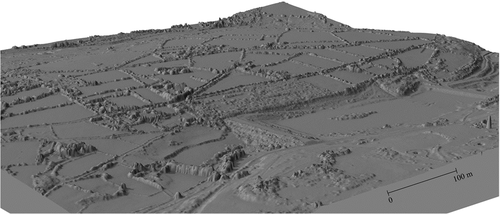

**Fig 2**

Open in figure viewer[PowerPoint](https://onlinelibrary.wiley.com/action/downloadFigures?id=brv12802-fig-0002&doi=10.1111%2Fbrv.12802)

A digital surface model (DSM) of the Wheal Maid valley in Cornwall produced from LiDAR data processed to 1 m spatial resolution. Created using the *EAlidaR* and *rayshader* R packages.

Data source: Environment Agency, UK

.

Increasingly, there is scope to combine both structural and reflectance data in the mapping of habitats. SfM techniques, for example, capture both structural and reflectance data simultaneously from aerial photographs (Westoby *et al*., 2012), enabling topography, structure and habitat characteristics to be mapped from drones at low cost and very high spatial resolutions (Cunliffe, Brazier & Anderson, 2016; Wallace *et al*., 2016; Fawcett *et al*., 2019). Reflectance data can also be co-registered with LiDAR or SAR data to facilitate habitat characterisation. Redhead *et al*. (2016), for example, used a combination of LiDAR-derived canopy heights and hyperspectral reflectance data to characterise landscape composition and its influence on the foraging distances of bumblebees. The launch of the Copernicus programme satellites, in particular, has greatly facilitated the availability of co-registered radar (Sentinel-1) and optical (Sentinel-2) satellite imagery, enabling improved classifications of habitat, for instance in regions where persistent cloud cover is an issue (Lopes *et al*., 2020).

## IV. INSECT MICROCLIMATES

The ability to remote sense habitat structure also enables the investigation of insect–microclimate interactions. Climate is fundamental in governing the physiology and ecology of organisms, playing a key role in driving the abundance, phenology and distribution of species (Clarke, 2017). Until very recently, however, there has been a great disparity between the scale at which climate variables are conventionally measured and the scale at which they are experienced by small organisms, such as insects (Potter, Woods & Pincebourde, 2013). Close to the ground, climate is modified by the effects of topography and vegetation to produce fine-scale variation in microclimate that is maintained by low wind speeds (Bramer *et al*., 2018). These microclimates characterise the thermal environments of most insects, but are often highly heterogeneous and vary markedly from the regional climate averages measured by standard meteorological stations (Suggitt *et al*., 2011). The inability to capture this fine-scale variation in climate across geographically extensive areas has been a major limitation to most climate studies of insects to date (Potter *et al*., 2013; Suggitt *et al*., 2017).

Remote sensing is increasingly able to provide environmental data at spatial scales that are physiologically relevant to insects. Crucially, whilst it has long been possible to collect single-point measurements of microclimate *in situ* with microsensors, remote sensing allows for microclimate variation to be mapped continuously across entire landscapes or regions (Zellweger *et al*., 2019). Through the use of remote-sensing products, it is now possible to determine the microclimate conditions of almost any given location and moment in time, leading to a paradigm shift in climate ecology research (Lembrechts & Lenoir, 2020).

### (1) Measuring microclimate

#### (a) *Surface temperature*

Drone-mounted thermal-imaging cameras can be used to map surface temperatures by directly measuring the TIR emitted by objects (Faye *et al*., 2016). Offering spatial resolutions of just a few centimetres, the resulting images provide a snapshot in time of surface temperatures across a landscape (Zellweger *et al*., 2019). Drone-based thermal imagery, for example, has been used for three-dimensional mapping of forest canopy surface temperatures (Webster *et al*., 2018) and to survey water surface temperature variation within river systems (Tonolla *et al*., 2012; Dugdale, Bergeron & St-Hilaire, 2015). Using canopy surface temperatures obtained in this way, for example, Faye *et al*. (2017) investigated the distribution and diversity of crop pests in relation to microclimate heterogeneity within potato fields. It is worth noting, however, that surface temperatures are not necessarily coupled to air temperatures, and so careful thought should be given to the appropriate measure of an organism's microclimate (Zellweger *et al*., 2019).

#### (b) *Water content*

Remote-sensing techniques can also provide direct measurements of soil moisture or leaf water content. The emission and backscattering of microwaves are strongly influenced by the water content of objects, allowing for variables such as soil moisture to be mapped (Kornelsen & Coulibaly, 2013). With high spatial and temporal resolution SAR data now available from satellite platforms, such as Sentinel-1, along with the development of algorithms to remove interference from surface roughness and vegetation (historically a major limitation with C- or X-band SAR), near-real time monitoring of soil moisture content at sub-100 m resolutions is now a very real possibility (Paloscia *et al*., 2013). Very few studies to date have used SAR soil moisture products for entomological purposes, but investigations are underway to develop its use as a means of forecasting the emergence of locust swarms (Crooks & Cheke, 2014; Escorihuela *et al*., 2018).

### (2) Modelling microclimate

An alternative approach to measuring microclimate directly is to model it. Modelling microclimate enables temperature and soil moisture conditions to be calculated at very fine spatiotemporal resolutions for almost any desired location or moment in time (Lembrechts & Lenoir, 2020) (Fig. 3). Modelling, therefore, can offer a more complete picture of microclimate variation through time and can also provide estimates for variables such as air and sub-surface soil temperatures that are not readily captured *via* direct sensing techniques (Bramer *et al*., 2018; Zellweger *et al*., 2019). A particular strength of modelling is that can be used to predict conditions under novel climate scenarios, allowing for past and future microclimate conditions to be (re)constructed (Bramer *et al*., 2018). In the context of entomology, this makes it highly valuable for predicting species' responses to climate change.

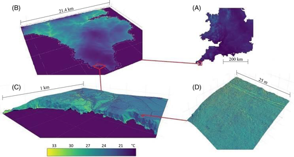

**Fig 3**

Open in figure viewer[PowerPoint](https://onlinelibrary.wiley.com/action/downloadFigures?id=brv12802-fig-0003&doi=10.1111%2Fbrv.12802)

Estimates of air temperature downscaled to increasingly fine spatial resolutions using the mechanistic microclimate model *Microclima*. (A) Standard weather station data set gridded at 5 km spatial resolution (macroclimate); (B) air temperature 1 m above ground at 100 m spatial resolution (mesoclimate); (C) air temperature 5 cm above ground at 1 m spatial resolution (microclimate); (D) air temperature 5 cm above ground at 2 cm spatial resolution (microclimate).

Microclimate models can either be statistical or mechanistic in nature. The former relies upon statistical associations of microclimate conditions with topography and vegetation to spatially interpolate data collected *in situ* with microsensors or to downscale regional climate data from weather stations (Bramer *et al*., 2018; Zellweger *et al*., 2019). Mechanistic models on the other hand, whilst driven by weather station data, use downscaling methods that simulate physical processes of heat and mass transfer to derive microclimate conditions (Bramer *et al*., 2018; Zellweger *et al*., 2019). Being mechanistic in process, they are generally considered to be more robust for making predictions under novel climates (Bramer *et al*., 2018). The complementary R packages *NicheMapR* (Kearney & Porter, 2017) and *Microclima* (Maclean, Mosedale & Bennie, 2019), for example, offer sophisticated approaches for mechanistically modelling microclimate. *NicheMapR* contains functions for calculating the full heat and water balance of soil/near-surface environments for point locations, whilst *Microclima* can capture mesoclimate effects, such as elevational cooling, wind shelter, coastal effects or cold air drainage, and is designed to provide gridded spatial estimates of conditions that also account for shading effects from topography and vegetation (Kearney *et al*., 2020).

Irrespective of the type of model used, however, all microclimate modelling is dependent on high-resolution digital elevation models (DEMs) to map three-dimensional structure across the landscape. Airborne LiDAR and, more recently, drone-based SfM techniques are ideally suited for this purpose, being able to capture topography and vegetation structure at centimetre spatial resolutions (Zellweger *et al*., 2019). Multispectral reflectance data can also be used in models, for instance as a measure of surface albedo or to provide estimates of canopy shading from NDVI-derived LAI (Maclean *et al*., 2019). The advent of very high spatial resolution remote sensing, therefore, has been vital in allowing for microclimate conditions to be modelled at scales that are relevant to insects.

### (3) Applications for microclimate

#### (a) *Population dynamics and phenology*

Being able to measure or model microclimate has enormous potential for improving forecasts of insect population dynamics and phenology. Rebaudo, Faye & Dangles (2016), for example, found that within-canopy air temperatures are a better predictor of local pest performance for three potato moth species than either regional (weather station) or global (WorldClim) climate data sets. Similarly, (meta)population models that incorporate variation in microclimate air temperatures have been shown by Bennie *et al*. (2013) to improve predictions of annual population densities and habitat patch occupancy for the silver-spotted skipper butterfly (*Hesperia comma*). It is even possible to model the body temperature of insects themselves under different environmental conditions (Kearney & Porter, 2020), opening the door to mechanistic models of insect growth, survival and fecundity in response to local climate conditions (Maino *et al*., 2016).

#### (b) *Species distribution modelling*

Efforts are also being made to incorporate microclimate variation into species distribution models (Lembrechts, Nijs & Lenoir, 2019). Hodgson *et al*. (2015), for example, have used microclimate variation to model the fine-scale distribution and density of silver-studded blue butterflies (*Plebejus argus*) across limestone grasslands in North Wales. Consideration of fine-scale variation in climate is particularly important when making predictions about species' responses to climate change, because local microclimate conditions are often partially decoupled from regional climate (Potter *et al*., 2013). A growing body of evidence suggests that microclimate heterogeneity can help to buffer organisms against broad-scale changes in climate, leading to very different predictions about their future range changes and extinction risk than if regional climate data sets are used (Potter *et al*., 2013; Scheffers *et al*., 2014; Maclean *et al*., 2015; Suggitt *et al*., 2018). Microclimate variation, derived from remote-sensing data, will be essential to make accurate predictions about how species respond to climate change (Potter *et al*., 2013; Suggitt *et al*., 2017).

## V. LIGHT POLLUTION

Artificial light at night (ALAN) is another important environmental variable in entomological research. The increasing prevalence of light pollution and growing concerns about disruption to species' behaviour, interactions and physiology has seen much focus in recent years on its potential ecological impacts (Owens & Lewis, 2018; Desouhant *et al*., 2019; Boyes *et al*., 2021; Grubisic & van Grunsven, 2021).

Imaging from Earth observation satellites can provide global monitoring of the brightness and extent of light pollution, allowing for changes in exposure to ALAN to be tracked across time and space (Bennie *et al*., 2014, 2015; Gaston, Duffy & Bennie, 2015; Levin *et al*., 2020; Li *et al*., 2020). To date, most readily available sources of night-time satellite imagery, such as VIIRS and DMSP, offer relatively coarse spatial resolution (750 and 3000 m, respectively) (Barentine, 2019; Levin *et al*., 2020). Due to the high sensitivity required for night-time imaging, this is also restricted to panchromatic sensors and hence information on the spectral properties of emitted light is not captured (Barentine, 2019; Levin *et al*., 2020).

Despite these limitations, satellite imagery offers a useful measure of site-level exposure to ALAN. Satellite-derived measurements of ALAN, for example, have been used to investigate temporal changes in light pollution with regards to its effects on pea aphid (*Acyrthosiphon pisum*) predation by ladybirds (Miller *et al*., 2017) and to assess the exposure of fireflies (*Amydetes fastigiate*) to light pollution within protected and non-protected areas of Atlantic rainforest (Vaz *et al*., 2021). Using a combination of ALAN data from VIIRS and radar-derived measurements of aerial insect abundance, Tielens *et al*. (2021) quantified the nocturnal movements of grasshopper swarms into urban areas as a result of attraction to light. Satellite data has also been used to investigate the phenological effects of light pollution on tree budburst (ffrench-Constant *et al*., 2016), suggesting potential for similar applications with insect phenology.

Looking to the future, a new generation of Earth observation satellites are starting to offer night-time images at higher spatial resolutions (in some cases sub-metre) and across multispectral bands (enabling spectral analysis of emitted light) (Levin *et al*., 2020). Higher spatial resolution data can also be obtained from aircraft platforms, which offer a greater end-user choice of spectral sensors (Kuechly *et al*., 2012). Aircraft-captured measurements of ALAN (1 m resolution), for example, have been used to investigate the effects of light pollution on the abundance and species richness of urban moth assemblages (Straka *et al*., 2021). The use of drones is also starting to be trialled, offering very high spatial resolutions and, likewise, the potential for greater flexibility in the capture of spectral data (Fiorentin, Bettanini & Bogoni, 2019; Bouroussis & Topalis, 2020; Tabaka, 2020).

## VI. INDIRECT DETECTION OF INSECTS

### (1) Insect feeding signs

On account of their small size, direct observation of insects is still well beyond the capabilities of most remote-sensing techniques (Pettorelli *et al*., 2014; Nowak *et al*., 2019). Although diminutive in size, insects can often be large in number and capable of having major influences on their surrounding environment (Leyequien *et al*., 2007). Effects such as defoliation and plant stress symptoms caused by insects are often readily observable with remote sensing and have a long history of being used to detect insects indirectly (Riley, 1989). Much of this research has occurred in an agricultural or forestry setting, where the early detection and monitoring of pest species forms a vital part of plant-protection strategies (Zhang *et al*., 2019). In these situations, remote sensing can scale up and automatise surveillance across large areas that would otherwise be prohibitively expensive and labour-intensive to monitor *via* conventional field surveys alone (Iost Filho *et al*., 2020). Remote sensing of insect pests has been extensively reviewed elsewhere (Senf *et al*., 2017; Zhang *et al*., 2019; Abd El-Ghany, Abd El-Aziz & Marei, 2020), so herein we provide only a brief overview.

#### (a) *Spectral feeding signs*

Feeding activity by insects causes loss of biomass and plant stress responses that can be detected from their spectral reflectance. Plant indices derived from multispectral satellite data, for example, have been extensively used for this purpose, particularly in the context of monitoring forest insect disturbances (Senf *et al*., 2017). Chief amongst these is NDVI, which, being a measure of photosynthetic activity, is sensitive to defoliation and plant die-off, but other indices, such as Enhanced Wetness Difference Index (EWDI), Normalised Burn Ratio (NBR), Moisture Stress Index (MSI) and Disturbance Index (DI), have also been widely used (Senf *et al*., 2017). Satellite-derived NDVI, for example, has been used to map spatiotemporal patterns of forest defoliation caused by moth caterpillars (Spruce *et al*., 2011; Olsson, Lindström & Eklundh, 2016) and sawfly larvae (Eklundh, Johansson & Solberg, 2009), and tree mortality induced by bark beetles (Hart & Veblen, 2015; Bryk, Kołodziej & Pliszka, 2021). High temporal resolution data are generally important for detecting defoliation pests due to the ephemeral nature of leaf loss (de Beurs & Townsend, 2008). Historically, therefore, most studies monitoring defoliators have had to rely on spatially coarse data, such as MODIS, in order to obtain the necessary temporal resolution (Rullan-Silva *et al*., 2013; Senf *et al*., 2017). Bark beetle infestations, on the other hand, are typically longer lasting in effect and so higher spatial resolution (but lower temporal resolution) data, such as Landsat, can be used (Wulder *et al*., 2006; Senf *et al*., 2017). It can be expected, therefore, that the recent availability of both high spatial and temporal resolution multispectral data from platforms such as Sentinel-2 should greatly facilitate satellite monitoring of short-lived disturbance events.

Spectral reflectance data from drones can now also be used for targeted inspections at very high spatial resolutions. This exceptional spatial detail can improve the detection accuracy of pest damage (Näsi *et al*., 2018), and is particularly well suited to field-scale surveys in agricultural settings, where low operational costs and user-defined revisit times allow for high frequency surveying (Iost Filho *et al*., 2020). Drones can also be equipped with a wider range of sensor types than are typically available from satellites (Iost Filho *et al*., 2020). Miniaturised hyperspectral sensors, for example, offer very high spectral resolutions that are able to detect the weak spectral changes associated with low infestation rates and the early stages of outbreaks (Zhang *et al*., 2019). Hyperspectral drone imagery, for example, has been used to detect bark beetle infestations in spruce forests (Näsi *et al*., 2015) and grape phylloxera (*Daktulosphaira vitifoliae*) infestations in vineyards (Vanegas *et al*., 2018), in some cases even allowing for detection before infestations become apparent through visual inspection (Vanegas *et al*., 2018). Increasingly, machine learning techniques are also being applied to hyperspectral data to improve and automate the detection of pests (Zhang *et al*., 2019).

#### (b) *Structural feeding signs*

Host-plant responses to insects can also be detected from changes in vegetation structure. LiDAR, for example, has been used to map the defoliation cause by gypsy moth (*Lymantria dispar*) caterpillars (Meng *et al*., 2018). In this particular study, LiDAR data outperformed that of hyperspectral sensors as a standalone means of detecting defoliation, although the best performance was achieved using models that included both structural and spectral information. Similarly, the increased availability of high spatial and temporal resolution SAR data has seen growing interest in the use of this technology to map forest insect disturbances (Hollaus & Vreugdenhil, 2019). Tanase *et al*. (2018), for example, used satellite SAR data to distinguish between forest disturbances caused by windthrow and bark beetle infestations in the Bavarian Forest National Park in Germany. A ground-based X-band radar system has also been used to estimate the abundance of the grasshopper *Heiroglyphus nigrorepletus* in sorghum fields from changes in total chlorophyll (Singh, Sao & Singh, 2007). Furthermore, the opportunity to combine both radar and optical data for monitoring insect disturbances can improve detection probabilities, especially for regions where persistent cloud cover is a major cause of interference (Ortiz, Breidenbach & Kändler, 2013; Hirschmugl *et al*., 2017).

### (2) Nest structures

Aside from the damage they cause to plants, insects may also be detected from the structures that they build. The nest mounds of certain ant and termite species, for example, form prominent features in the landscape that are readily distinguishable at the spatial resolution of aerial photographs (Vogt, 2004*b*; Isabelle *et al*., 2014; Sandino, Wooler & Gonzalez, 2017) and even satellite imagery (Vogt, 2004*a*; Mujinya *et al*., 2014). Most species in studies to date typically make large (0.5 to >10 m in diameter) and sparsely vegetated mounds, providing a strong contrast with the surrounding vegetation. Shadow effects (Isabelle *et al*., 2014) and a ring of vigorous vegetation growth fringing mounds may also help to accentuate them (Vogt, 2004*a*, 2004*b*; Sandino *et al*., 2017). Spectral imaging of nest mounds has typically used RGB, panchromatic or NIR bands, with the accuracy of mound detection influenced by both mound characteristics (height, area, nest activity, vegetation cover) and the imaging method (spectral bands and resolution). Airborne LiDAR has also been deployed to map the nest mounds of *Macrotermes* termites remotely, not only allowing for the detection of nest mound locations, but also providing information on mound architecture (Levick *et al*., 2010; Davies *et al*., 2014; Davies, Baldeck & Asner, 2016). Drone-based SfM could also be deployed for these purposes, although to our knowledge, SfM has only been attempted for nest mounds using ground-based systems to date (Nauer *et al*., 2018; Vesala *et al*., 2019).

For both spectral and structural approaches, mound size has a considerable influence on the detection probability of nest mounds (Vogt, 2004*a*, 2004*b*; Davies *et al*., 2014; Isabelle *et al*., 2014; Sandino *et al*., 2017). Higher spatial resolution images from drones may help to address this issue, along with substantially reducing the operational costs of collecting aerial photographs (Anderson & Gaston, 2013). Increasingly, efforts are also being made to automate nest mound identification through the use of image segmentation algorithms and machine learning (Levick *et al*., 2010; Davies *et al*., 2014, 2016; Sandino *et al*., 2017). At present, however, remote-sensing data have a limited ability to infer the activity status of nests or to identify the species involved (Bala Ahmed II & Pradhan, 2018). As a complement to conventional field surveys, however, it can offer a valuable means of scaling up data collection to a landscape scale.

## VII. DIRECT DETECTION OF INSECTS

### (1) Vertical-looking radar

It has been known for more than 70 years that radar is capable of detecting individual flying insects and radar systems have been used by entomologists for this purpose since the late 1960s (Riley *et al*., 2007). During the last couple of decades, however, the development of VLR, in particular, has had a transformative effect on the monitoring of aerial insects (Chapman *et al*., 2011). VLR systems emit a conical X-band radar beam up into the sky, in which the linear plane of polarisation is continually rotated (Smith, Riley & Gregory, 1993; Chapman *et al*., 2003). The beam itself also nutates (wobbles) around the vertical axis, which enables the horizontal position and the mass of objects to be determined (Smith *et al*., 1993). Any insect (of approximately ≥1 mg mass) passing through this beam will reflect a signal back to the ground-based receiver, from which information on its shape, mass, altitude (assigned to a series of discrete height bands), body alignment, horizontal position and speed, and direction of travel can be estimated (Smith *et al*., 1993; Chapman *et al*., 2002*b*, 2003). With beam nutation turned off, it is also possible to measure wingbeat frequency, however this precludes estimates of body mass (Chapman *et al*., 2003). From shape, body mass and/or wingbeat frequency data, insects can be assigned to functional groups, although complementary sampling/observation of specimens is necessary for species identification in most cases (Chapman *et al*., 2003). Operation of the system is entirely autonomous (unlike earlier scanning radar systems), making it well suited for long-term monitoring (Chapman *et al*., 2002*b*, 2003).

VLR has been used to quantify seasonal and diurnal patterns of insect migration for taxa such as hoverflies (Wotton *et al*., 2019), ladybirds (Jeffries *et al*., 2013) and Lepidoptera (Chapman *et al*., 2002*a*; Wood *et al*., 2009; Stefanescu *et al*., 2013). It has also allowed investigation of the vertical layering of flying insects in relation to atmospheric conditions (Reynolds *et al*., 2005; Reynolds, Smith & Chapman, 2008; Wood *et al*., 2010) and provided insights into the behavioural adaptations of insect migrants, such as flight orientation, the selection of favourable air flows and correction for crosswind drift (Chapman *et al*., 2008*a*, 2008*b*, 2010).

### (2) Harmonic radar

Close to the ground, returning radar signals from flying insects are liable to be masked by much stronger echoes coming from ground features and vegetation (Riley *et al*., 2007). Consequently, VLR is only suitable for detecting insects at high altitude, typically between a range of 150 and 1200 m above the transmitter (Chapman & Reynolds, 2004). Where the detection of low-flying insects is required, one solution is to use harmonic radar. Here, a transponder fitted to the insect receives the incoming radar signal and re-emits a signal at a different frequency, allowing it to be differentiated from the echoes generated by ground features and vegetation (Riley *et al*., 2007). In this way it is possible to track the movement of tagged insects at low altitudes, over distances of a kilometre or so. For example, harmonic radar has been used to track the movement of butterflies (Cant *et al*., 2005; Ovaskainen *et al*., 2008) and to investigate the foraging and orientation behaviours of bumblebees (Osborne *et al*., 1999, 2013; Lihoreau *et al*., 2012; Woodgate *et al*., 2016) and honeybees (Capaldi *et al*., 2000; Riley *et al*., 2005). It has also been used to study the pheromone-plume locating behaviour of male moths (Reynolds *et al*., 2007) and to locate the nests of Asian hornets (*Vespa velutina*) by tracking tagged workers back to their colonies (Maggiora *et al*., 2019).

### (3) Entomological LiDAR

Another approach for detecting low-flying insects at close range is the development of entomological LiDAR. Being a much shorter wavelength than microwaves (Fig. 1), NIR avoids many of the issues of signal clutter from ground features or vegetation, and also offers far greater range resolution and the capability of detecting much smaller insects (<1 mg) than radar (Brydegaard, 2015; Brydegaard & Jansson, 2019). Insects flying through the laser beam produce a backscatter signal from which their position, cross-sectional area and wingbeat frequency can be determined (Brydegaard & Jansson, 2019). Spectral analysis of the backscatter can also provide information on molecular composition and microstructure (Brydegaard, 2015), whilst from the depolarisation of the returning signal it is possible to differentiate surface textures and thus partition contributions from furry insect bodies and glossy wings (Shaw *et al*., 2005). LiDAR, for example, has been used to detect damselflies flying over a stream (Guan *et al*., 2010), to measure temporal (Zhu *et al*., 2017; Malmqvist *et al*., 2018) and spatiotemporal (Kirkeby, Wellenreuther & Brydegaard, 2016; Tauc *et al*., 2019) patterns of flying insect abundance, and to map densities of honeybees trained to detect landmines (Shaw *et al*., 2005). At present, the ability to classify insects into species or functional groups from field LiDAR data remains poor (Brydegaard, 2015; Kirkeby *et al*., 2016), but laboratory experiments show promise for being able to distinguish species and even sexes from optical cross section, wingbeat frequency and spectral properties, aided by machine learning techniques (Moore & Miller, 2002; Brydegaard *et al*., 2009; Brydegaard, 2015; Gebru *et al*., 2018; Genoud *et al*., 2018). Using fluorescent powder to mark insects, it is also possible to use LiDAR to track individuals (Guan *et al*., 2010; Mei *et al*., 2012). The fluorescent powder produces a distinctive spectral signal from which the individual can be identified, akin to harmonic radar, but without the need for the cumbersome transponders which are limited to use on larger insects (Mei *et al*., 2012). Powder tagging can be used to track the dispersal of insects or to generate population estimates through mark-without-recapture (Brydegaard & Jansson, 2019).

### (4) Passive sensing of insects

As the spatial resolution of sensors continues to improve, a limited number of opportunities for passive sensing are also starting to emerge. Drones flying at very low altitudes, for example, can capture photographs from which it is possible to distinguish large, conspicuous species, such as butterflies (Ivosevic, Han & Kwon, 2017). It is conceivable that such methods could be used for surveying insects in inaccessible locations, such as the forest canopy, although at present the probability of detecting individuals *via* such methods remains unknown. Another promising avenue is the use of thermal imaging to detect insect aggregations. Communal clusters of insects can often raise their collective body temperatures substantially above that of the surrounding environment through basking and/or generating metabolic heat (Porter, 1982; Heaton, Moffatt & Simmons, 2014). Hand-held thermal infrared cameras, for example, are used commercially to detect the presence of termite colonies within buildings (Reynolds & Riley, 2002), whilst aircraft-mounted thermal infrared cameras have been used to locate carcasses from the heat generated by fly maggots feeding within them (Lee *et al*., 2018). Very high spatial resolution drone thermal imagery, for example, has been used to locate aggregations of marsh fritillary caterpillars (*Euphydryas aurinia*) basking on their larval webs in early spring (R. J. Curtis, unpublished data). The effectiveness of such methods, however, is likely to vary depending on the climatic conditions at the time of survey (Lee *et al*., 2018).

## VIII. FUTURE PROSPECTS

As remote-sensing technology continues to develop and become more affordable, new opportunities are emerging for entomological research. In this section, we highlight some of the exciting potential for advances in the field that we believe to be approaching.

### (1) Dynamic niche mapping

The unprecedented spatial and temporal resolution now offered by remote-sensing products will revolutionise the way we study species' niches. At high spatial resolutions, the individual resources that an insect requires no longer occur within the same habitat pixel. Instead, an insect will be moving between different pixel classifications at different stages of its life cycle and even during a single day. The suitability of individual pixels will also vary through time, as resources become available or disappear, or an insect's requirements change during its life. Similarly, the microclimate suitability of habitat pixels will wax and wane with climatic variation from year to year, day to day and hour to hour (Bennie *et al*., 2013). At these fine scales, habitat ceases to be a static classification, but rather a series of dynamic maps of multiple, overlapping resources (Dennis *et al*., 2003, 2006). With available remote-sensing products able to quantify the conditions that insects experience, there is now a very real possibility of capturing the dynamics of shifting niche space, opening the door to more mechanistic models of habitat suitability and species' distribution (Kearney & Porter, 2009).

### (2) Drone-based LiDAR

Until recently, airborne LiDAR data has been limited to aircraft-mounted systems, constraining both the spatial and temporal resolution of data (Kellner *et al*., 2019). Drone-mounted LiDAR systems capable of acquiring data at much lower altitudes are, however, becoming increasingly affordable and we anticipate their widespread uptake in ecological research within the next decade. These systems offer very dense point clouds of three-dimensional structure, comparable in detail to that of TLS (Wallace *et al*., 2016; Kellner *et al*., 2019) and superior to SfM in discerning below-canopy structure (White *et al*., 2013; Wallace *et al*., 2016). Such phenomenally high spatial resolution, coupled with the temporal flexibility afforded by drone platforms, could offer rapid monitoring of changes in vegetation structure, such as that caused by insect defoliation. With spatial resolutions sufficient to resolve tree branching structure, drone LiDAR data might even enable important structural habitat features, such as standing deadwood or potential nest-site locations, to be identified. There is also potential for LiDAR data to offer additional information on vegetation composition or status through techniques such as laser-induced fluorescence. Spectroscopic analysis of the returning backscatter can be used to detect plant stress symptoms or to assist with species identification (Günther, Dahn & Lüdeker, 1994; Yang *et al*., 2016).

### (3) Monitoring migration at continental scale

Entomological radar is currently on the verge of massively scaling up its geographical coverage of insect migration. Strategically arranged VLRs could be used to track the arrival of migrant insects across regions, for example to provide forecasts of crop pest risk (Chapman *et al*., 2011). Perhaps more exciting, however, is the potential for using data from existing networks of weather radars, offering near-continuous geographical coverage across entire countries or even continents (Chilson *et al*., 2012; Bauer *et al*., 2017). Weather radar data is already providing new insights into bird migration (Farnsworth *et al*., 2016; Dokter *et al*., 2018; Nilsson *et al*., 2019), and early investigations suggest good potential for its application within entomology. In North America, for example, weather radar has been used successfully to determine the abundance, displacement speed and direction of migrating corn earworm moths (*Helicoverpa zea*) (Westbrook, Eyster & Wolf, 2014) around the Texas–Mexico border, and to investigate the movement of grasshopper swarms in response to urban light pollution (Tielens *et al*., 2021). In Europe, the BioDAR project is currently developing a library of weather radar signatures for different insect functional groups and has a citizen science project using weather radar to investigate the nuptial flights of alate ants [see https://biodarproject.org/]. It seems highly probable that continental-scale monitoring of flying insect abundance and movements will become a reality within the next decade.

## IX. CONCLUSIONS

1. Remote sensing increasingly offers a powerful range of tools for studying the incredible abundance and diversity of insect life on this planet. With the spatial and temporal resolution of remote-sensing products continuing to improve, it is increasingly possible to work at the scales necessary for studying insects, enabling new insights into their behaviour, ecology and conservation.
2. Satellite and airborne sensors are capable of capturing information on the composition and structure of insect habitats, increasingly at sufficient resolutions for individual habitat resources to be distinguished. Climate conditions can also be mapped at scales physiologically relevant to insects – either by direct measurement with remote sensing or by capturing topographical and structural data from which microclimate conditions can be modelled. Similarly, satellite and airborne platforms also provide opportunities for monitoring the levels of light pollution that insect populations are exposed to.
3. Remote sensing can also be used to detect the presence of insects. Optical and structural data can be used to detect insects indirectly from the environmental effects that they induce, whilst radar and LiDAR enable flying insects to be directly observed or tracked. Increasingly, limited opportunities for the passive direct sensing of insects are also becoming available.
4. As remote-sensing technology continues to develop, we see great potential arising from the co-ordination of platforms/sensors and device miniaturisation to scale-up geographical coverage and to present new sensing opportunities. We hope to encourage more entomologists to consider remote-sensing methods within the remit of their research.

## X. ACKNOWLEDGMENTS

We thank an anonymous reviewer for their helpful and constructive comments, and Karin Hale and Stephen Hale for proofreading. We are also grateful to the University of Exeter College of Life and Environmental Sciences, Cornwall Butterfly and Moth Society, and Spalding Associates (Environmental) Ltd for supporting M.W.R. with a funded PhD studentship.

## Citing Literature

[figure not shown]

[Volume97, Issue1](https://onlinelibrary.wiley.com/toc/1469185x/2022/97/1)

February 2022

Pages 343-360

### Recommended

  [Ecological Monographs](https://esajournals.onlinelibrary.wiley.com/journal/15577015)

[Download PDF](https://onlinelibrary.wiley.com/doi/pdf/10.1111/brv.12802)

back